# PREDICT_PARADIGM: Model Validity of PREDICT v2.2 and v2.3

Yuwei Wang

2023-09-22

# READ ME

The R script is designed for our manuscript entitled the external validation and clinical utility assessment of PREDICT breast cancer prognostic model in young women with node-negative breast cancer. This R script assessed the performance of PREDICT v2.2 and PREDICT v2.3 in all women diagnosed with node-negative breast cancer. Using the script, we generated results for Table 3, Supplementary Table 1 and Supplementary Table 2. # Load the libraries

```r
library(readxl)
library(readr)
library(dplyr)
library(plyr)
library(rms)
library(ggplot2)
library(survminer)
library(survival)
library(splines)
library(knitr)
library(table1)
library(boot)
library(tidyverse)
library(rsample)
library(timeROC)
library(pec)
library(riskRegression)
library(ggplot2)
```

# Load the imputed datasets

In the previous script, we performed multiple imputation and ran the PREDICT v2.2 and v2.3 algorithms in the imputed dataset. After runing the two models, we generated v2.2-predicted and v2.3-predicted all-cause mortality. The two datasets are named as dataimpute_v22 and dataimpute_v23, respecitively.

We excluded women under 25, as PREDICT doesn’t provide predictions for women under 25.

```r
## all women
df_v22 <- dataimpute_v22 %>%
  filter(T_LEEFT >= 25) %>%
  mutate(intrsub = ifelse((er == 1 | pr == 1) & her2 == 0, "HRposHER2neg",
       ifelse((er == 1| pr == 1) & her2 == 1, "HRposHER2pos",
              ifelse(er == 0 & pr == 0 & her2 == 0, "HRnegHER2neg",
                     ifelse(er == 0 & pr == 0 & her2 == 1, "HRnegHER2pos", NA)))))

## women with ER-positive tumors
df_v22_ERpos <- df_v22 %>%
        filter(ER.num > 0)
## women with ER-negative tumors
df_v22_ERneg <- df_v22 %>%
        filter(ER.num == 0)

## women of each subtype
df_v22_HRposHER2neg <- df_v22 %>%
  filter(intrsub == "HRposHER2neg")

df_v22_HRposHER2pos <- df_v22 %>%
  filter(intrsub == "HRposHER2pos")

df_v22_HRnegHER2pos <- df_v22 %>%
  filter(intrsub == "HRnegHER2pos")

df_v22_HRnegHER2neg <- df_v22 %>%
  filter(intrsub == "HRnegHER2neg")

### women of TNBC with gBRCA1/2m or gBRCA1/2wt
df_v22_HRnegHER2neg_gBRCA12m <- df_v22_HRnegHER2neg %>%
  filter(gBRCA12 == 1)
df_v22_HRnegHER2neg_gBRCA12wt <- df_v22_HRnegHER2neg %>%
  filter(gBRCA12 == 0)
```

```r
## all women
df_v23 <- dataimpute_v23 %>%
  filter(T_LEEFT >= 25) %>%
  mutate(intrsub = ifelse((er == 1 | pr == 1) & her2 == 0, "HRposHER2neg",
       ifelse((er == 1| pr == 1) & her2 == 1, "HRposHER2pos",
              ifelse(er == 0 & pr == 0 & her2 == 0, "HRnegHER2neg",
                     ifelse(er == 0 & pr == 0 & her2 == 1, "HRnegHER2pos", NA)))))

## women with ER-positive tumors
df_v23_ERpos <- df_v23 %>%
        filter(ER.num > 0)
## women with ER-negative tumors
df_v23_ERneg <- df_v23 %>%
        filter(ER.num == 0)

## women of each subtype
df_v23_HRposHER2neg <- df_v23 %>%
  filter(intrsub == "HRposHER2neg")

df_v23_HRposHER2pos <- df_v23 %>%
  filter(intrsub == "HRposHER2pos")

df_v23_HRnegHER2pos <- df_v23 %>%
  filter(intrsub == "HRnegHER2pos")

df_v23_HRnegHER2neg <- df_v23 %>%
  filter(intrsub == "HRnegHER2neg")

### women of TNBC with gBRCA1/2m or gBRCA1/2wt
df_v23_HRnegHER2neg_gBRCA12m <- df_v23_HRnegHER2neg %>%
  filter(gBRCA12 == 1)
df_v23_HRnegHER2neg_gBRCA12wt <- df_v23_HRnegHER2neg %>%
  filter(gBRCA12 == 0)
```

# Load functions

We made several functions for pooling results of calibration and discrimination.

## Functions for pooling estimates

pool_estimate can pool the results from estimation and the corresponding standard error of each imputed dataset, and was adapted from the pool_auc function from the package psfmi.This function follows Rubin’s rule (note that the estimation is not log-transformed). The function returns the pooled estimation and 95% confidence interval.

```r
pool_estimate <- function(est, se, nimp) {
  RR_se <- function(est, se, nimp){ # a function to calculate total SE
    m <- nimp
    w_var <- mean(se^2) # within variance
    b_var <- var(est) # between variance
    t_var <- w_var + (1 + (1/m)) * b_var # total variance
    se_total <- sqrt(t_var) # total se
    r <- (1 + 1 / m) * (b_var / w_var)
    v <- (m - 1) * (1 + (1/r))^2 #degree of freedom
    t <- qt(0.975, v)
    res <- c(se_total, t)
    return(res)
  }

  est <- unlist(est)
  se <- unlist(se)
  if(length(est) != nimp)
    stop("Include c-statistic value for each imputed dataset")

  mean_est <- format(round(mean(est), 2), nsmall = 2)
  se_total <- RR_se(est, se, nimp=nimp)
  uCI <- format(round(mean(est) + (se_total[2]*se_total[1]), 2), nsmall = 2)
  lCI <- format(round(mean(est) - (se_total[2]*se_total[1]), 2), nsmall = 2)

  res <- paste0(mean_est, " (", lCI, "-", uCI, ")")

  return(res)
}
```

## Function for pooling data for calibration plot

pool_caliplot was only slightly different from pool_estimation. It returns the pooled estiamtion, lower 95% confidence interval and upper 95% confidence interval separately.

```r
pool_caliplot <- function(est, se, nimp) {
  RR_se <- function(est, se, nimp){ # a function to calculate total SE
    m <- nimp
    w_var <- mean(se^2) # within variance
    b_var <- var(est) # between variance
    t_var <- w_var + (1 + (1/m)) * b_var # total variance
    se_total <- sqrt(t_var) # total se
    r <- (1 + 1 / m) * (b_var / w_var)
    v <- (m - 1) * (1 + (1/r))^2 #degree of freedom
    t <- qt(0.975, v)
    res <- c(se_total, t)
    return(res)
  }

  est <- unlist(est)
  se <- unlist(se)
  if(length(est) != nimp)
    stop("Include c-statistic value for each imputed dataset")

  mean_est <- mean(est)
  se_total <- RR_se(est, se, nimp=nimp)
  uCI <- mean(est) + (se_total[2]*se_total[1])
  lCI <- mean(est) - (se_total[2]*se_total[1])

  res <- c(mean_est,  lCI,  uCI)

  return(res)
}
```

pool_caliplot_df returns a dataset that can be used to generate calibration plots. The function first divides women into quintiles based on their expected risks. Then the observed risks and its lower and upper confidence intervals are calculated, as well as the mean of the expected risks in each quintile.

```r
pool_caliplot_df <- function(data, time, status, impvar, nimp, predmort, tmax) {
    res_obs <- matrix(NA, nimp, 5)
    res_se <- matrix(NA, nimp, 5)
    res_exp <- matrix(NA, nimp, 5)

    for (i in 1:nimp) {

      df <- data[data[impvar] == i, ]

      q5 <- cut(df[, predmort],
                breaks = quantile(df[, predmort], probs = seq(0, 1, 0.20)), include.lowest = TRUE)

      df$risk_q5 <- factor(q5, levels = levels(q5), labels = c('q1', 'q2', 'q3', 'q4', "q5"))

      exp_risk <- tapply(df[, predmort], df[, "risk_q5"], mean)

      surv_fit <- survfit(Surv(df[, time], df[, status]) ~ df[, "risk_q5"])
      #obs_surv5 <- survfit(Surv(timeyr, delta) ~ q5_5yr_f, data = df)
      obs_risk <- 1 - summary(surv_fit ,times = tmax)$surv
      obs_se <- summary(surv_fit ,times = tmax)$std.err

      res_obs[i, ] <- obs_risk
      res_se[i, ] <- obs_se
      res_exp[i, ] <- exp_risk
    }

    # Pool
    pool_obs_q1 <- pool_caliplot(res_obs[, 1], res_se[, 1], nimp = nimp)
    pool_obs_q2 <- pool_caliplot(res_obs[, 2], res_se[, 2], nimp = nimp)
    pool_obs_q3 <- pool_caliplot(res_obs[, 3], res_se[, 3], nimp = nimp)
    pool_obs_q4 <- pool_caliplot(res_obs[, 4], res_se[, 4], nimp = nimp)
    pool_obs_q5 <- pool_caliplot(res_obs[, 5], res_se[, 5], nimp = nimp)

    pool_exp <- colMeans(res_exp)

    caliplot_df <- cbind(rbind(pool_obs_q1, pool_obs_q2,
                               pool_obs_q3, pool_obs_q4,
                               pool_obs_q5), pool_exp) %>%
      as.data.frame(.)
    names(caliplot_df) <- c("obs.y", "obs.lower", "obs.upper", "exp.x")

    return(caliplot_df)
}
```

## Functions for pooling O/E ratios and AUC

pool_OEratio computes observed risk and its standard errors, as well as the mean of the expected risk to calculate O/E ratio, i.e. the ratio between observed and expected risks. In addition, it also returns the number of events during different follow-up times.

```r
pool_OEratio <- function(data, time, status, impvar, nimp, predmort, tmax) {
    res <- matrix(NA, nimp, 4)
    # a results matrix for O/E ratio, se of O/E ratio, number of patients and number of events

    for (i in 1:nimp) {

      df <- data[data[impvar] == i, ]
      nwomen <- dim(df)[1]

      surv_fit <- survfit(Surv(df[, time], df[, status]) ~ 1)

      obs_risk <- 1 - summary(surv_fit, times = tmax)$surv
      obs_se <- summary(surv_fit, times = tmax)$std.err
      nevent <- summary(surv_fit, times = tmax)$n.event

      exp_risk <- mean(df[, predmort])

      # O/E ratio
      OE_stats <- obs_risk / exp_risk
      se_OE_stats <- obs_se / exp_risk

      res[i, ] <- c(OE_stats, se_OE_stats, nwomen, nevent)
    }

    # Pool
    pool_OE <- pool_estimate(res[, 1], res[, 2], nimp = nimp)

    nwomen <- round(median(res[, 3]), 0)
    nevent <- median(res[, 4])


    return(c(nwomen, nevent, pool_OE))
}
```

pool_AUC computes AUC and its 95% confidence interval. This function contains timeROC from timeROC pacakge.

```r
pool_AUC <- function(data, time, status, impvar, nimp, predmort, tmax) {
    res <- matrix(NA, nimp, 2)

    for (i in 1:nimp) {

      df <- data[data[impvar] == i, ]

      tAUC <- timeROC(T = df[, time], delta = df[, status],
                  marker = df[, predmort], weighting="marginal",
                  times = tmax, cause = 1, ROC = F, iid = TRUE)

      res[i, ] <- c(tAUC$AUC[2], tAUC$inference$vect_sd_1[2])
    }

    # Pool
    pool_AUCres <- pool_estimate(res[, 1], res[, 2], nimp = nimp)

    return(pool_AUCres)
}
```

# Performance of PREDICT v2.2

## Calibration in the large

```r
#10-year
OE10_v22_all <- pool_OEratio(df_v22, "timeyr", "delta", ".imp", 50, "all10", tmax = 10)
OE10_v22_ERpos <- pool_OEratio(df_v22_ERpos, "timeyr", "delta", ".imp", 50, "all10", tmax = 10)
OE10_v22_ERneg <- pool_OEratio(df_v22_ERneg, "timeyr", "delta", ".imp", 50, "all10", tmax = 10)
OE10_v22_HRposHER2neg <- pool_OEratio(df_v22_HRposHER2neg, "timeyr", "delta", ".imp", 50, "all10", tmax = 10)
OE10_v22_HRposHER2pos <- pool_OEratio(df_v22_HRposHER2pos, "timeyr", "delta", ".imp", 50, "all10", tmax = 10)
OE10_v22_HRnegHER2pos <- pool_OEratio(df_v22_HRnegHER2pos, "timeyr", "delta", ".imp", 50, "all10", tmax = 10)
OE10_v22_HRnegHER2neg <- pool_OEratio(df_v22_HRnegHER2neg, "timeyr", "delta", ".imp", 50, "all10", tmax = 10)
OE10_v22_HRnegHER2neg_gBRCA12m  <- pool_OEratio(df_v22_HRnegHER2neg_gBRCA12m , "timeyr", "delta", ".imp", 50, "all10", tmax = 10)
OE10_v22_HRnegHER2neg_gBRCA12wt <- pool_OEratio(df_v22_HRnegHER2neg_gBRCA12wt , "timeyr", "delta", ".imp", 50, "all10", tmax = 10)

res_OE10_v22 <- matrix(c(OE10_v22_all, OE10_v22_ERpos, OE10_v22_ERneg,
                         OE10_v22_HRposHER2neg, OE10_v22_HRposHER2pos, OE10_v22_HRnegHER2pos, OE10_v22_HRnegHER2neg,
                         OE10_v22_HRnegHER2neg_gBRCA12m, OE10_v22_HRnegHER2neg_gBRCA12wt),
                    nrow=9, byrow=T,
                    dimnames = list(c('All women','ER-positive','ER-negative',
                                      'HRposHER2neg', 'HRposHER2pos', 'HRnegHER2pos', 'HRnegHER2neg',
                                      'gBRCA12m', 'gBRCA12wt'),
                                (c('v22_No.women', 'v22_No.event', 'v22_O/E ratio'))))

res_OE10_v22
```

```
##              v22_No.women v22_No.event v22_O/E ratio
## All women    "2264"       "492"        "1.33 (1.22-1.43)"
## ER-positive  "1614"       "330"        "1.45 (1.31-1.59)"
## ER-negative  "650"        "162"        "1.13 (0.97-1.29)"
## HRposHER2neg "1376"       "244"        "1.37 (1.21-1.53)"
## HRposHER2pos "274"        "94"         "1.65 (1.37-1.94)"
## HRnegHER2pos "106"        "29"         "1.08 (0.73-1.43)"
## HRnegHER2neg "506"        "124"        "1.15 (0.96-1.33)"
## gBRCA12m     "98"         "31"         "1.46 (1.03-1.88)"
## gBRCA12wt    "282"        "66"         "1.09 (0.86-1.32)"
```

```r
#5-year and-15 year
OE5_v22_all <- pool_OEratio(df_v22, "timeyr", "delta", ".imp", 50, "all5", tmax = 5)
OE5_v22_ERpos <- pool_OEratio(df_v22_ERpos, "timeyr", "delta", ".imp", 50, "all5", tmax = 5)
OE5_v22_ERneg <- pool_OEratio(df_v22_ERneg, "timeyr", "delta", ".imp", 50, "all5", tmax = 5)
OE5_v22_HRposHER2neg <- pool_OEratio(df_v22_HRposHER2neg, "timeyr", "delta", ".imp", 50, "all5", tmax = 5)
OE5_v22_HRposHER2pos <- pool_OEratio(df_v22_HRposHER2pos, "timeyr", "delta", ".imp", 50, "all5", tmax = 5)
OE5_v22_HRnegHER2pos <- pool_OEratio(df_v22_HRnegHER2pos, "timeyr", "delta", ".imp", 50, "all5", tmax = 5)
OE5_v22_HRnegHER2neg <- pool_OEratio(df_v22_HRnegHER2neg, "timeyr", "delta", ".imp", 50, "all5", tmax = 5)
OE5_v22_HRnegHER2neg_gBRCA12m  <- pool_OEratio(df_v22_HRnegHER2neg_gBRCA12m , "timeyr", "delta", ".imp", 50, "all5", tmax = 5)
OE5_v22_HRnegHER2neg_gBRCA12wt <- pool_OEratio(df_v22_HRnegHER2neg_gBRCA12wt , "timeyr", "delta", ".imp", 50, "all5", tmax = 5)


OE15_v22_all <- pool_OEratio(df_v22, "timeyr", "delta", ".imp", 50, "all15", tmax = 15)
OE15_v22_ERpos <- pool_OEratio(df_v22_ERpos, "timeyr", "delta", ".imp", 50, "all15", tmax = 15)
OE15_v22_ERneg <- pool_OEratio(df_v22_ERneg, "timeyr", "delta", ".imp", 50, "all15", tmax = 15)
OE15_v22_HRposHER2neg <- pool_OEratio(df_v22_HRposHER2neg, "timeyr", "delta", ".imp", 50, "all15", tmax = 15)
OE15_v22_HRposHER2pos <- pool_OEratio(df_v22_HRposHER2pos, "timeyr", "delta", ".imp", 50, "all15", tmax = 15)
OE15_v22_HRnegHER2pos <- pool_OEratio(df_v22_HRnegHER2pos, "timeyr", "delta", ".imp", 50, "all15", tmax = 15)
OE15_v22_HRnegHER2neg <- pool_OEratio(df_v22_HRnegHER2neg, "timeyr", "delta", ".imp", 50, "all15", tmax = 15)
OE15_v22_HRnegHER2neg_gBRCA12m  <- pool_OEratio(df_v22_HRnegHER2neg_gBRCA12m , "timeyr", "delta", ".imp", 50, "all15", tmax = 15)
OE15_v22_HRnegHER2neg_gBRCA12wt <- pool_OEratio(df_v22_HRnegHER2neg_gBRCA12wt , "timeyr", "delta", ".imp", 50, "all15", tmax = 15)
```

## Calibration plot

We made a calibration plot of PREDICT v2.2 in all women, women with ER-positive tumors and women with ER-negative tumors.

```r
calplot10_dfv22 <- pool_caliplot_df(df_v22, "timeyr", "delta", ".imp", 50, "all10", tmax = 10)
calplot10_dfv22_ERpos <- pool_caliplot_df(df_v22_ERpos, "timeyr", "delta", ".imp", 50, "all10", tmax = 10)
calplot10_dfv22_ERneg <- pool_caliplot_df(df_v22_ERneg, "timeyr", "delta", ".imp", 50, "all10", tmax = 10)
```

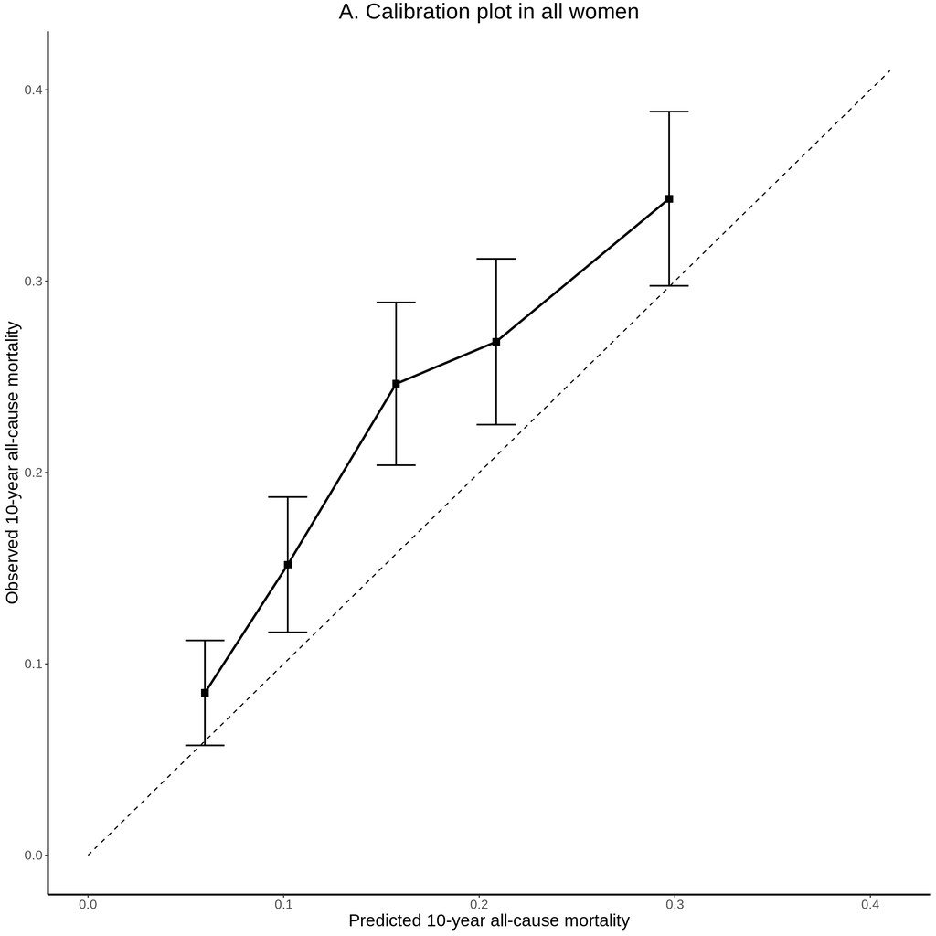

```r
caliplot_dfv22_all <-
  ggplot(calplot10_dfv22, aes(x = exp.x, y = obs.y)) +
  geom_point(color = "black", size = 3, shape = 15) +
  geom_line(color = "black", size = 1) +
  #abline! I used geomline instead of abline because I could specify the length of the abline
  geom_line(data = data.frame(x = c(0, 0.41), y = c(0, 0.41)),
            aes(x, y), color = "black", linetype = "dashed") +
  geom_errorbar(aes(ymin = obs.lower, ymax = obs.upper),
                width = 0.02, color = "black", size = 0.7) +
  #geom_vline(xintercept = 0.12, color = "red", linetype = "dashed") +
  xlim(0, 0.41) + ylim(0, 0.41) +
  xlab("Predicted 10-year all-cause mortality") +
  ylab("Observed 10-year all-cause mortality") +
  ggtitle("A. Calibration plot in all women") +
  theme(plot.title = element_text(hjust = 0.5, vjust = 1.5, size = 20),
        text = element_text(family = "Arial"),
        panel.background = element_rect(fill = "white"),
        axis.title = element_text(size = 16),
        axis.line = element_line(color = "black", linewidth = 0.8),
        axis.text = element_text(size = 12))
caliplot_dfv22_all
```

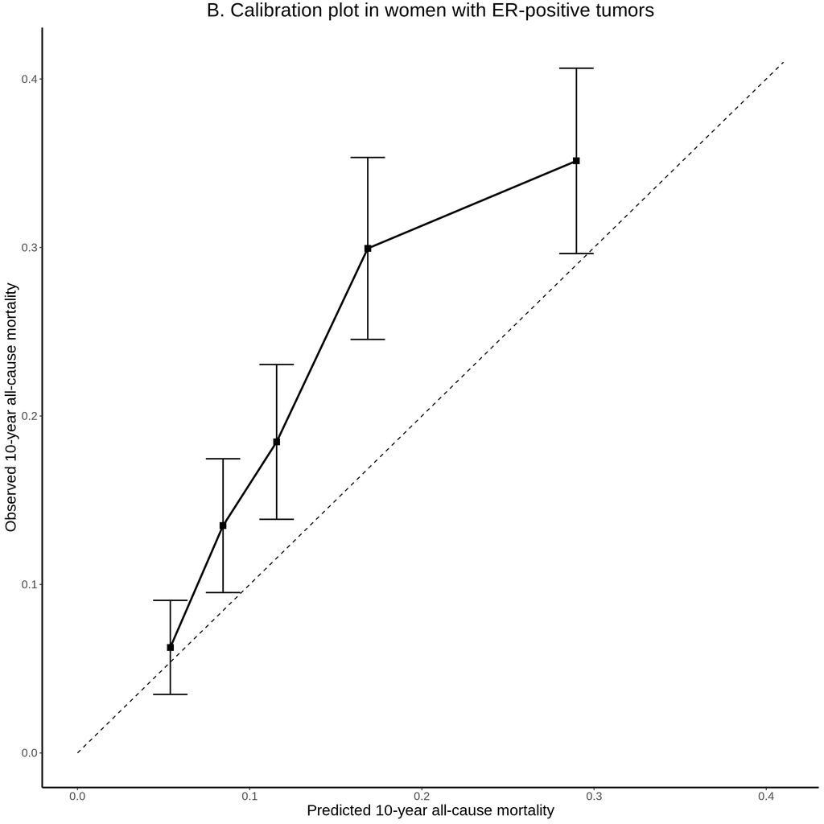

```r
caliplot_dfv22_ERpos <-
  ggplot(calplot10_dfv22_ERpos, aes(x = exp.x, y = obs.y)) +
  geom_point(color = "black", size = 3, shape = 15) +
  geom_line(color = "black", size = 1) +
  #abline! I used geomline instead of abline because I could specify the length of the abline
  geom_line(data = data.frame(x = c(0, 0.41), y = c(0, 0.41)),
            aes(x, y), color = "black", linetype = "dashed") +
  geom_errorbar(aes(ymin = obs.lower, ymax = obs.upper),
                width = 0.02, color = "black", size = 0.7) +
  #geom_vline(xintercept = 0.12, color = "red", linetype = "dashed") +
  xlim(0, 0.41) + ylim(0, 0.41) +
  xlab("Predicted 10-year all-cause mortality") +
  ylab("Observed 10-year all-cause mortality") +
  ggtitle("B. Calibration plot in women with ER-positive tumors") +
  theme(plot.title = element_text(hjust = 0.5, vjust = 1.5, size = 20),
        text = element_text(family = "Arial"),
        panel.background = element_rect(fill = "white"),
        axis.title = element_text(size = 16),
        axis.line = element_line(color = "black", linewidth = 0.8),
        axis.text = element_text(size = 12))
caliplot_dfv22_ERpos
```

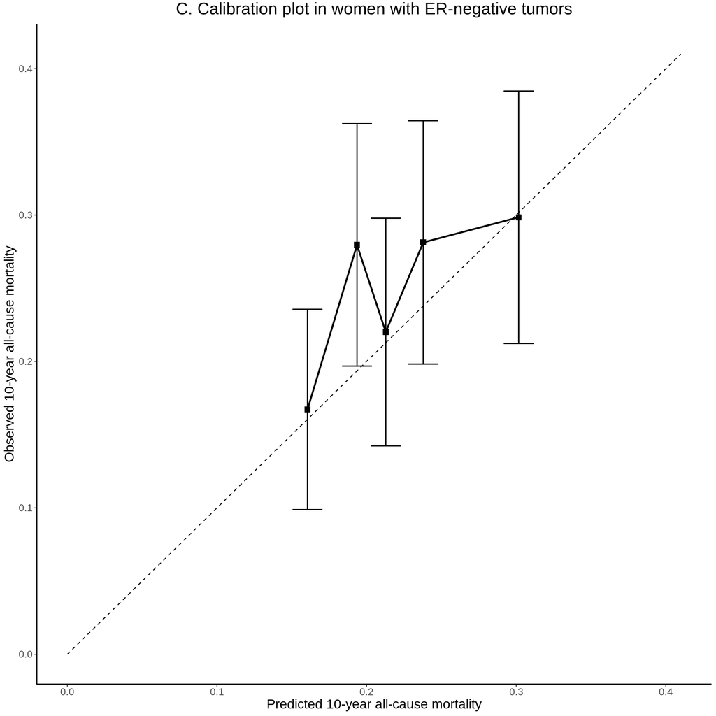

```r
caliplot_dfv22_ERneg <-
  ggplot(calplot10_dfv22_ERneg, aes(x = exp.x, y = obs.y)) +
  geom_point(color = "black", size = 3, shape = 15) +
  geom_line(color = "black", size = 1) +
  #abline! I used geomline instead of abline because I could specify the length of the abline
  geom_line(data = data.frame(x = c(0, 0.41), y = c(0, 0.41)),
            aes(x, y), color = "black", linetype = "dashed") +
  geom_errorbar(aes(ymin = obs.lower, ymax = obs.upper),
                width = 0.02, color = "black", size = 0.7) +
  #geom_vline(xintercept = 0.12, color = "red", linetype = "dashed") +
  xlim(0, 0.41) + ylim(0, 0.41) +
  xlab("Predicted 10-year all-cause mortality") +
  ylab("Observed 10-year all-cause mortality") +
  ggtitle("C. Calibration plot in women with ER-negative tumors") +
  theme(plot.title = element_text(hjust = 0.5, vjust = 1.5, size = 20),
        text = element_text(family = "Arial"),
        panel.background = element_rect(fill = "white"),
        axis.title = element_text(size = 16),
        axis.line = element_line(color = "black", linewidth = 0.8),
        axis.text = element_text(size = 12))
caliplot_dfv22_ERneg
```

## Discrimination

Discrimination ability was calculated using time-dependent area under the ROC curve.

```r
#10-year
AUC10_v22_all <- pool_AUC(df_v22, "timeyr", "delta", ".imp", 50, "all10", tmax = 10)
AUC10_v22_ERpos <- pool_AUC(df_v22_ERpos, "timeyr", "delta", ".imp", 50, "all10", tmax = 10)
AUC10_v22_ERneg <- pool_AUC(df_v22_ERneg, "timeyr", "delta", ".imp", 50, "all10", tmax = 10)
AUC10_v22_HRposHER2neg <- pool_AUC(df_v22_HRposHER2neg, "timeyr", "delta", ".imp", 50, "all10", tmax = 10)
AUC10_v22_HRposHER2pos <- pool_AUC(df_v22_HRposHER2pos, "timeyr", "delta", ".imp", 50, "all10", tmax = 10)
AUC10_v22_HRnegHER2pos <- pool_AUC(df_v22_HRnegHER2pos, "timeyr", "delta", ".imp", 50, "all10", tmax = 10)
AUC10_v22_HRnegHER2neg <- pool_AUC(df_v22_HRnegHER2neg, "timeyr", "delta", ".imp", 50, "all10", tmax = 10)
AUC10_v22_HRnegHER2neg_gBRCA12m  <- pool_AUC(df_v22_HRnegHER2neg_gBRCA12m , "timeyr", "delta", ".imp", 50, "all10", tmax = 10)
AUC10_v22_HRnegHER2neg_gBRCA12wt <- pool_AUC(df_v22_HRnegHER2neg_gBRCA12wt , "timeyr", "delta", ".imp", 50, "all10", tmax = 10)

res_AUC10_v22 <- matrix(c(AUC10_v22_all, AUC10_v22_ERpos, AUC10_v22_ERneg,
                         AUC10_v22_HRposHER2neg, AUC10_v22_HRposHER2pos, AUC10_v22_HRnegHER2pos, AUC10_v22_HRnegHER2neg,
                         AUC10_v22_HRnegHER2neg_gBRCA12m, AUC10_v22_HRnegHER2neg_gBRCA12wt),
                    nrow=9, byrow=T,
                    dimnames = list(c('All women','ER-positive','ER-negative',
                                      'HRposHER2neg', 'HRposHER2pos', 'HRnegHER2pos', 'HRnegHER2neg',
                                      'gBRCA12m', 'gBRCA12wt'),
                                (c('v22_AUC'))))

res_AUC10_v22
```

```
##              v22_AUC
## All women    "0.65 (0.62-0.68)"
## ER-positive  "0.69 (0.65-0.72)"
## ER-negative  "0.56 (0.51-0.62)"
## HRposHER2neg "0.68 (0.64-0.72)"
## HRposHER2pos "0.57 (0.50-0.64)"
## HRnegHER2pos "0.55 (0.42-0.68)"
## HRnegHER2neg "0.55 (0.48-0.61)"
## gBRCA12m     "0.51 (0.38-0.64)"
## gBRCA12wt    "0.56 (0.48-0.64)"
```

```r
#5-year and 15-year
AUC5_v22_all <- pool_AUC(df_v22, "timeyr", "delta", ".imp", 50, "all5", tmax = 5)
AUC5_v22_ERpos <- pool_AUC(df_v22_ERpos, "timeyr", "delta", ".imp", 50, "all5", tmax = 5)
AUC5_v22_ERneg <- pool_AUC(df_v22_ERneg, "timeyr", "delta", ".imp", 50, "all5", tmax = 5)
AUC5_v22_HRposHER2neg <- pool_AUC(df_v22_HRposHER2neg, "timeyr", "delta", ".imp", 50, "all5", tmax = 5)
AUC5_v22_HRposHER2pos <- pool_AUC(df_v22_HRposHER2pos, "timeyr", "delta", ".imp", 50, "all5", tmax = 5)
AUC5_v22_HRnegHER2pos <- pool_AUC(df_v22_HRnegHER2pos, "timeyr", "delta", ".imp", 50, "all5", tmax = 5)
AUC5_v22_HRnegHER2neg <- pool_AUC(df_v22_HRnegHER2neg, "timeyr", "delta", ".imp", 50, "all5", tmax = 5)
AUC5_v22_HRnegHER2neg_gBRCA12m  <- pool_AUC(df_v22_HRnegHER2neg_gBRCA12m , "timeyr", "delta", ".imp", 50, "all5", tmax = 5)
AUC5_v22_HRnegHER2neg_gBRCA12wt <- pool_AUC(df_v22_HRnegHER2neg_gBRCA12wt , "timeyr", "delta", ".imp", 50, "all5", tmax = 5)


AUC15_v22_all <- pool_AUC(df_v22, "timeyr", "delta", ".imp", 50, "all15", tmax = 15)
AUC15_v22_ERpos <- pool_AUC(df_v22_ERpos, "timeyr", "delta", ".imp", 50, "all15", tmax = 15)
AUC15_v22_ERneg <- pool_AUC(df_v22_ERneg, "timeyr", "delta", ".imp", 50, "all15", tmax = 15)
AUC15_v22_HRposHER2neg <- pool_AUC(df_v22_HRposHER2neg, "timeyr", "delta", ".imp", 50, "all15", tmax = 15)
AUC15_v22_HRposHER2pos <- pool_AUC(df_v22_HRposHER2pos, "timeyr", "delta", ".imp", 50, "all15", tmax = 15)
AUC15_v22_HRnegHER2pos <- pool_AUC(df_v22_HRnegHER2pos, "timeyr", "delta", ".imp", 50, "all15", tmax = 15)
AUC15_v22_HRnegHER2neg <- pool_AUC(df_v22_HRnegHER2neg, "timeyr", "delta", ".imp", 50, "all15", tmax = 15)
AUC15_v22_HRnegHER2neg_gBRCA12m  <- pool_AUC(df_v22_HRnegHER2neg_gBRCA12m , "timeyr", "delta", ".imp", 50, "all15", tmax = 15)
AUC15_v22_HRnegHER2neg_gBRCA12wt <- pool_AUC(df_v22_HRnegHER2neg_gBRCA12wt , "timeyr", "delta", ".imp", 50, "all15", tmax = 15)
```

# Performance of PREDICT v2.3

## Calibration in the large

```r
#10-year
OE10_v23_all <- pool_OEratio(df_v23, "timeyr", "delta", ".imp", 50, "all10", tmax = 10)
OE10_v23_ERpos <- pool_OEratio(df_v23_ERpos, "timeyr", "delta", ".imp", 50, "all10", tmax = 10)
OE10_v23_ERneg <- pool_OEratio(df_v23_ERneg, "timeyr", "delta", ".imp", 50, "all10", tmax = 10)
OE10_v23_HRposHER2neg <- pool_OEratio(df_v23_HRposHER2neg, "timeyr", "delta", ".imp", 50, "all10", tmax = 10)
OE10_v23_HRposHER2pos <- pool_OEratio(df_v23_HRposHER2pos, "timeyr", "delta", ".imp", 50, "all10", tmax = 10)
OE10_v23_HRnegHER2pos <- pool_OEratio(df_v23_HRnegHER2pos, "timeyr", "delta", ".imp", 50, "all10", tmax = 10)
OE10_v23_HRnegHER2neg <- pool_OEratio(df_v23_HRnegHER2neg, "timeyr", "delta", ".imp", 50, "all10", tmax = 10)
OE10_v23_HRnegHER2neg_gBRCA12m  <- pool_OEratio(df_v23_HRnegHER2neg_gBRCA12m , "timeyr", "delta", ".imp", 50, "all10", tmax = 10)
OE10_v23_HRnegHER2neg_gBRCA12wt <- pool_OEratio(df_v23_HRnegHER2neg_gBRCA12wt , "timeyr", "delta", ".imp", 50, "all10", tmax = 10)

res_OE10_v23 <- matrix(c(OE10_v23_all, OE10_v23_ERpos, OE10_v23_ERneg,
                         OE10_v23_HRposHER2neg, OE10_v23_HRposHER2pos, OE10_v23_HRnegHER2pos, OE10_v23_HRnegHER2neg,
                         OE10_v23_HRnegHER2neg_gBRCA12m, OE10_v23_HRnegHER2neg_gBRCA12wt),
                    nrow=9, byrow=T,
                    dimnames = list(c('All women','ER-positive','ER-negative',
                                      'HRposHER2neg', 'HRposHER2pos', 'HRnegHER2pos', 'HRnegHER2neg',
                                      'gBRCA12m', 'gBRCA12wt'),
                                (c('v23_No.women', 'v23_No.event', 'v23_O/E ratio'))))

res_OE10_v23
```

```
##              v23_No.women v23_No.event v23_O/E ratio
## All women    "2264"       "492"        "1.32 (1.22-1.43)"
## ER-positive  "1614"       "330"        "1.45 (1.31-1.60)"
## ER-negative  "650"        "162"        "1.11 (0.96-1.27)"
## HRposHER2neg "1376"       "244"        "1.39 (1.22-1.55)"
## HRposHER2pos "274"        "94"         "1.64 (1.36-1.92)"
## HRnegHER2pos "106"        "29"         "1.05 (0.71-1.39)"
## HRnegHER2neg "506"        "124"        "1.12 (0.94-1.30)"
## gBRCA12m     "98"         "31"         "1.42 (1.01-1.84)"
## gBRCA12wt    "282"        "66"         "1.06 (0.84-1.29)"
```

```r
#5-year and-15 year
OE5_v23_all <- pool_OEratio(df_v23, "timeyr", "delta", ".imp", 50, "all5", tmax = 5)
OE5_v23_ERpos <- pool_OEratio(df_v23_ERpos, "timeyr", "delta", ".imp", 50, "all5", tmax = 5)
OE5_v23_ERneg <- pool_OEratio(df_v23_ERneg, "timeyr", "delta", ".imp", 50, "all5", tmax = 5)
OE5_v23_HRposHER2neg <- pool_OEratio(df_v23_HRposHER2neg, "timeyr", "delta", ".imp", 50, "all5", tmax = 5)
OE5_v23_HRposHER2pos <- pool_OEratio(df_v23_HRposHER2pos, "timeyr", "delta", ".imp", 50, "all5", tmax = 5)
OE5_v23_HRnegHER2pos <- pool_OEratio(df_v23_HRnegHER2pos, "timeyr", "delta", ".imp", 50, "all5", tmax = 5)
OE5_v23_HRnegHER2neg <- pool_OEratio(df_v23_HRnegHER2neg, "timeyr", "delta", ".imp", 50, "all5", tmax = 5)
OE5_v23_HRnegHER2neg_gBRCA12m  <- pool_OEratio(df_v23_HRnegHER2neg_gBRCA12m , "timeyr", "delta", ".imp", 50, "all5", tmax = 5)
OE5_v23_HRnegHER2neg_gBRCA12wt <- pool_OEratio(df_v23_HRnegHER2neg_gBRCA12wt , "timeyr", "delta", ".imp", 50, "all5", tmax = 5)


OE15_v23_all <- pool_OEratio(df_v23, "timeyr", "delta", ".imp", 50, "all15", tmax = 15)
OE15_v23_ERpos <- pool_OEratio(df_v23_ERpos, "timeyr", "delta", ".imp", 50, "all15", tmax = 15)
OE15_v23_ERneg <- pool_OEratio(df_v23_ERneg, "timeyr", "delta", ".imp", 50, "all15", tmax = 15)
OE15_v23_HRposHER2neg <- pool_OEratio(df_v23_HRposHER2neg, "timeyr", "delta", ".imp", 50, "all15", tmax = 15)
OE15_v23_HRposHER2pos <- pool_OEratio(df_v23_HRposHER2pos, "timeyr", "delta", ".imp", 50, "all15", tmax = 15)
OE15_v23_HRnegHER2pos <- pool_OEratio(df_v23_HRnegHER2pos, "timeyr", "delta", ".imp", 50, "all15", tmax = 15)
OE15_v23_HRnegHER2neg <- pool_OEratio(df_v23_HRnegHER2neg, "timeyr", "delta", ".imp", 50, "all15", tmax = 15)
OE15_v23_HRnegHER2neg_gBRCA12m  <- pool_OEratio(df_v23_HRnegHER2neg_gBRCA12m , "timeyr", "delta", ".imp", 50, "all15", tmax = 15)
OE15_v23_HRnegHER2neg_gBRCA12wt <- pool_OEratio(df_v23_HRnegHER2neg_gBRCA12wt , "timeyr", "delta", ".imp", 50, "all15", tmax = 15)
```

## Discrimination

Discrimination ability was calculated using time-dependent area under the ROC curve.

```r
#10-year
AUC10_v23_all <- pool_AUC(df_v23, "timeyr", "delta", ".imp", 50, "all10", tmax = 10)
AUC10_v23_ERpos <- pool_AUC(df_v23_ERpos, "timeyr", "delta", ".imp", 50, "all10", tmax = 10)
AUC10_v23_ERneg <- pool_AUC(df_v23_ERneg, "timeyr", "delta", ".imp", 50, "all10", tmax = 10)
AUC10_v23_HRposHER2neg <- pool_AUC(df_v23_HRposHER2neg, "timeyr", "delta", ".imp", 50, "all10", tmax = 10)
AUC10_v23_HRposHER2pos <- pool_AUC(df_v23_HRposHER2pos, "timeyr", "delta", ".imp", 50, "all10", tmax = 10)
AUC10_v23_HRnegHER2pos <- pool_AUC(df_v23_HRnegHER2pos, "timeyr", "delta", ".imp", 50, "all10", tmax = 10)
AUC10_v23_HRnegHER2neg <- pool_AUC(df_v23_HRnegHER2neg, "timeyr", "delta", ".imp", 50, "all10", tmax = 10)
AUC10_v23_HRnegHER2neg_gBRCA12m  <- pool_AUC(df_v23_HRnegHER2neg_gBRCA12m , "timeyr", "delta", ".imp", 50, "all10", tmax = 10)
AUC10_v23_HRnegHER2neg_gBRCA12wt <- pool_AUC(df_v23_HRnegHER2neg_gBRCA12wt , "timeyr", "delta", ".imp", 50, "all10", tmax = 10)

res_AUC10_v23 <- matrix(c(AUC10_v23_all, AUC10_v23_ERpos, AUC10_v23_ERneg,
                         AUC10_v23_HRposHER2neg, AUC10_v23_HRposHER2pos, AUC10_v23_HRnegHER2pos, AUC10_v23_HRnegHER2neg,
                         AUC10_v23_HRnegHER2neg_gBRCA12m, AUC10_v23_HRnegHER2neg_gBRCA12wt),
                    nrow=9, byrow=T,
                    dimnames = list(c('All women','ER-positive','ER-negative',
                                      'HRposHER2neg', 'HRposHER2pos', 'HRnegHER2pos', 'HRnegHER2neg',
                                      'gBRCA12m', 'gBRCA12wt'),
                                (c('v23_AUC'))))

res_AUC10_v23
```

```
##              v23_AUC
## All women    "0.65 (0.62-0.68)"
## ER-positive  "0.69 (0.66-0.72)"
## ER-negative  "0.56 (0.51-0.62)"
## HRposHER2neg "0.69 (0.65-0.72)"
## HRposHER2pos "0.57 (0.50-0.64)"
## HRnegHER2pos "0.55 (0.42-0.68)"
## HRnegHER2neg "0.55 (0.48-0.61)"
## gBRCA12m     "0.51 (0.38-0.64)"
## gBRCA12wt    "0.56 (0.48-0.64)"
```

```r
#5-year and 15-year
AUC5_v23_all <- pool_AUC(df_v23, "timeyr", "delta", ".imp", 50, "all5", tmax = 5)
AUC5_v23_ERpos <- pool_AUC(df_v23_ERpos, "timeyr", "delta", ".imp", 50, "all5", tmax = 5)
AUC5_v23_ERneg <- pool_AUC(df_v23_ERneg, "timeyr", "delta", ".imp", 50, "all5", tmax = 5)
AUC5_v23_HRposHER2neg <- pool_AUC(df_v23_HRposHER2neg, "timeyr", "delta", ".imp", 50, "all5", tmax = 5)
AUC5_v23_HRposHER2pos <- pool_AUC(df_v23_HRposHER2pos, "timeyr", "delta", ".imp", 50, "all5", tmax = 5)
AUC5_v23_HRnegHER2pos <- pool_AUC(df_v23_HRnegHER2pos, "timeyr", "delta", ".imp", 50, "all5", tmax = 5)
AUC5_v23_HRnegHER2neg <- pool_AUC(df_v23_HRnegHER2neg, "timeyr", "delta", ".imp", 50, "all5", tmax = 5)
AUC5_v23_HRnegHER2neg_gBRCA12m  <- pool_AUC(df_v23_HRnegHER2neg_gBRCA12m , "timeyr", "delta", ".imp", 50, "all5", tmax = 5)
AUC5_v23_HRnegHER2neg_gBRCA12wt <- pool_AUC(df_v23_HRnegHER2neg_gBRCA12wt , "timeyr", "delta", ".imp", 50, "all5", tmax = 5)


AUC15_v23_all <- pool_AUC(df_v23, "timeyr", "delta", ".imp", 50, "all15", tmax = 15)
AUC15_v23_ERpos <- pool_AUC(df_v23_ERpos, "timeyr", "delta", ".imp", 50, "all15", tmax = 15)
AUC15_v23_ERneg <- pool_AUC(df_v23_ERneg, "timeyr", "delta", ".imp", 50, "all15", tmax = 15)
AUC15_v23_HRposHER2neg <- pool_AUC(df_v23_HRposHER2neg, "timeyr", "delta", ".imp", 50, "all15", tmax = 15)
AUC15_v23_HRposHER2pos <- pool_AUC(df_v23_HRposHER2pos, "timeyr", "delta", ".imp", 50, "all15", tmax = 15)
AUC15_v23_HRnegHER2pos <- pool_AUC(df_v23_HRnegHER2pos, "timeyr", "delta", ".imp", 50, "all15", tmax = 15)
AUC15_v23_HRnegHER2neg <- pool_AUC(df_v23_HRnegHER2neg, "timeyr", "delta", ".imp", 50, "all15", tmax = 15)
AUC15_v23_HRnegHER2neg_gBRCA12m  <- pool_AUC(df_v23_HRnegHER2neg_gBRCA12m , "timeyr", "delta", ".imp", 50, "all15", tmax = 15)
AUC15_v23_HRnegHER2neg_gBRCA12wt <- pool_AUC(df_v23_HRnegHER2neg_gBRCA12wt , "timeyr", "delta", ".imp", 50, "all15", tmax = 15)
```

## Results summary

### Table 3

```r
res_10 <- cbind(res_OE10_v22, res_AUC10_v22, res_OE10_v23, res_AUC10_v23) %>%
  as_tibble()
res_10
```

```
## # A tibble: 9 × 8
##   v22_No.women v22_No.event v22_O/E ra…¹ v22_AUC v23_N…² v23_N…³ v23_O…⁴ v23_AUC
##   <chr>        <chr>        <chr>        <chr>   <chr>   <chr>   <chr>   <chr>
## 1 2264         492          1.33 (1.22-… 0.65 (… 2264    492     1.32 (… 0.65 (…
## 2 1614         330          1.45 (1.31-… 0.69 (… 1614    330     1.45 (… 0.69 (…
## 3 650          162          1.13 (0.97-… 0.56 (… 650     162     1.11 (… 0.56 (…
## 4 1376         244          1.37 (1.21-… 0.68 (… 1376    244     1.39 (… 0.69 (…
## 5 274          94           1.65 (1.37-… 0.57 (… 274     94      1.64 (… 0.57 (…
## 6 106          29           1.08 (0.73-… 0.55 (… 106     29      1.05 (… 0.55 (…
## 7 506          124          1.15 (0.96-… 0.55 (… 506     124     1.12 (… 0.55 (…
## 8 98           31           1.46 (1.03-… 0.51 (… 98      31      1.42 (… 0.51 (…
## 9 282          66           1.09 (0.86-… 0.56 (… 282     66      1.06 (… 0.56 (…
## # … with abbreviated variable names ¹`v22_O/E ratio`, ²v23_No.women,
## #   ³v23_No.event, ⁴`v23_O/E ratio`
```

### Suapplmentary Table 1

```r
s_res_v22 <- matrix(c(OE5_v22_all, AUC5_v22_all,
                    OE15_v22_all, AUC15_v22_all,
                    OE5_v22_ERpos, AUC5_v22_ERpos,
                    OE15_v22_ERpos, AUC15_v22_ERpos,
                    OE5_v22_ERneg, AUC5_v22_ERneg,
                    OE15_v22_ERneg, AUC15_v22_ERneg,
                    OE5_v22_HRposHER2neg, AUC5_v22_HRposHER2neg,
                    OE15_v22_HRposHER2neg, AUC15_v22_HRposHER2neg,
                    OE5_v22_HRposHER2pos, AUC5_v22_HRposHER2pos,
                    OE15_v22_HRposHER2pos, AUC15_v22_HRposHER2pos,
                    OE5_v22_HRnegHER2pos, AUC5_v22_HRnegHER2pos,
                    OE15_v22_HRnegHER2pos, AUC15_v22_HRnegHER2pos,
                    OE5_v22_HRnegHER2neg, AUC5_v22_HRnegHER2neg,
                    OE15_v22_HRnegHER2neg, AUC15_v22_HRnegHER2neg,
                    OE5_v22_HRnegHER2neg_gBRCA12m, AUC5_v22_HRnegHER2neg_gBRCA12m,
                    OE15_v22_HRnegHER2neg_gBRCA12m, AUC15_v22_HRnegHER2neg_gBRCA12m,
                    OE5_v22_HRnegHER2neg_gBRCA12wt, AUC5_v22_HRnegHER2neg_gBRCA12wt,
                    OE15_v22_HRnegHER2neg_gBRCA12wt, AUC15_v22_HRnegHER2neg_gBRCA12wt),
                    nrow=9, byrow=T,
                    dimnames = list(c('All women','ER-positive','ER-negative',
                                      'HRposHER2neg', 'HRposHER2pos', 'HRnegHER2pos', 'HRnegHER2neg',
                                      'gBRCA12m', 'gBRCA12wt'),
                                (c('No.women5', 'No.event5', 'O/E ratio5', 'AUC5',
                                   'No.women15', 'No.event15', 'O/E ratio15', 'AUC15'))))

s_res_v22
```

```
##              No.women5 No.event5 O/E ratio5         AUC5
## All women    "2264"    "284"     "1.46 (1.30-1.62)" "0.70 (0.67-0.73)"
## ER-positive  "1614"    "151"     "1.64 (1.39-1.90)" "0.72 (0.68-0.76)"
## ER-negative  "650"     "133"     "1.30 (1.09-1.50)" "0.57 (0.51-0.63)"
## HRposHER2neg "1376"    "105.5"   "1.44 (1.17-1.72)" "0.72 (0.67-0.77)"
## HRposHER2pos "274"     "52"      "2.18 (1.63-2.73)" "0.61 (0.52-0.70)"
## HRnegHER2pos "106"     "23"      "1.16 (0.73-1.60)" "0.56 (0.42-0.70)"
## HRnegHER2neg "506"     "103"     "1.33 (1.10-1.57)" "0.56 (0.50-0.63)"
## gBRCA12m     "98"      "26"      "1.70 (1.14-2.27)" "0.51 (0.38-0.65)"
## gBRCA12wt    "282"     "58"      "1.34 (1.03-1.65)" "0.58 (0.49-0.66)"
##              No.women15 No.event15 O/E ratio15        AUC15
## All women    "2264"     "630"      "1.22 (1.14-1.30)" "0.63 (0.61-0.66)"
## ER-positive  "1614"     "448"      "1.27 (1.17-1.37)" "0.66 (0.63-0.69)"
## ER-negative  "650"      "182"      "1.11 (0.97-1.25)" "0.56 (0.51-0.61)"
## HRposHER2neg "1376"     "349"      "1.26 (1.15-1.38)" "0.65 (0.62-0.69)"
## HRposHER2pos "274"      "108"      "1.27 (1.07-1.46)" "0.57 (0.50-0.64)"
## HRnegHER2pos "106"      "33"       "1.05 (0.74-1.37)" "0.56 (0.43-0.69)"
## HRnegHER2neg "506"      "140"      "1.12 (0.96-1.29)" "0.54 (0.48-0.60)"
## gBRCA12m     "98"       "36"       "1.47 (1.09-1.85)" "0.52 (0.39-0.64)"
## gBRCA12wt    "282"      "71"       "1.02 (0.81-1.22)" "0.56 (0.48-0.64)"
```

### Suapplmentary Table 2

```r
s_res_v23 <- matrix(c(OE5_v23_all, AUC5_v23_all,
                    OE15_v23_all, AUC15_v23_all,
                    OE5_v23_ERpos, AUC5_v23_ERpos,
                    OE15_v23_ERpos, AUC15_v23_ERpos,
                    OE5_v23_ERneg, AUC5_v23_ERneg,
                    OE15_v23_ERneg, AUC15_v23_ERneg,
                    OE5_v23_HRposHER2neg, AUC5_v23_HRposHER2neg,
                    OE15_v23_HRposHER2neg, AUC15_v23_HRposHER2neg,
                    OE5_v23_HRposHER2pos, AUC5_v23_HRposHER2pos,
                    OE15_v23_HRposHER2pos, AUC15_v23_HRposHER2pos,
                    OE5_v23_HRnegHER2pos, AUC5_v23_HRnegHER2pos,
                    OE15_v23_HRnegHER2pos, AUC15_v23_HRnegHER2pos,
                    OE5_v23_HRnegHER2neg, AUC5_v23_HRnegHER2neg,
                    OE15_v23_HRnegHER2neg, AUC15_v23_HRnegHER2neg,
                    OE5_v23_HRnegHER2neg_gBRCA12m, AUC5_v23_HRnegHER2neg_gBRCA12m,
                    OE15_v23_HRnegHER2neg_gBRCA12m, AUC15_v23_HRnegHER2neg_gBRCA12m,
                    OE5_v23_HRnegHER2neg_gBRCA12wt, AUC5_v23_HRnegHER2neg_gBRCA12wt,
                    OE15_v23_HRnegHER2neg_gBRCA12wt, AUC15_v23_HRnegHER2neg_gBRCA12wt),
                    nrow=9, byrow=T,
                    dimnames = list(c('All women','ER-positive','ER-negative',
                                      'HRposHER2neg', 'HRposHER2pos', 'HRnegHER2pos', 'HRnegHER2neg',
                                      'gBRCA12m', 'gBRCA12wt'),
                                (c('No.women5', 'No.event5', 'O/E ratio5', 'AUC5',
                                   'No.women15', 'No.event15', 'O/E ratio15', 'AUC15'))))

s_res_v23
```

```
##              No.women5 No.event5 O/E ratio5         AUC5
## All women    "2264"    "284"     "1.45 (1.29-1.61)" "0.70 (0.67-0.73)"
## ER-positive  "1614"    "151"     "1.64 (1.39-1.89)" "0.72 (0.68-0.76)"
## ER-negative  "650"     "133"     "1.28 (1.08-1.47)" "0.57 (0.51-0.63)"
## HRposHER2neg "1376"    "105.5"   "1.46 (1.18-1.74)" "0.72 (0.67-0.77)"
## HRposHER2pos "274"     "52"      "2.16 (1.61-2.70)" "0.62 (0.53-0.70)"
## HRnegHER2pos "106"     "23"      "1.13 (0.71-1.56)" "0.56 (0.42-0.70)"
## HRnegHER2neg "506"     "103"     "1.30 (1.07-1.53)" "0.56 (0.50-0.63)"
## gBRCA12m     "98"      "26"      "1.66 (1.11-2.21)" "0.51 (0.38-0.65)"
## gBRCA12wt    "282"     "58"      "1.30 (1.00-1.60)" "0.57 (0.49-0.66)"
##              No.women15 No.event15 O/E ratio15        AUC15
## All women    "2264"     "630"      "1.21 (1.13-1.29)" "0.63 (0.61-0.66)"
## ER-positive  "1614"     "448"      "1.27 (1.17-1.37)" "0.66 (0.63-0.69)"
## ER-negative  "650"      "182"      "1.09 (0.96-1.23)" "0.56 (0.50-0.61)"
## HRposHER2neg "1376"     "349"      "1.27 (1.16-1.39)" "0.65 (0.62-0.69)"
## HRposHER2pos "274"      "108"      "1.26 (1.07-1.45)" "0.58 (0.51-0.65)"
## HRnegHER2pos "106"      "33"       "1.03 (0.72-1.34)" "0.56 (0.43-0.69)"
## HRnegHER2neg "506"      "140"      "1.10 (0.94-1.26)" "0.54 (0.48-0.60)"
## gBRCA12m     "98"       "36"       "1.44 (1.06-1.81)" "0.52 (0.39-0.64)"
## gBRCA12wt    "282"      "71"       "0.99 (0.79-1.19)" "0.56 (0.48-0.64)"
```